# Untitled

# 8 Markdown syntax- Page breaks.

Markdown allows for the specification of page breaks in your document.  
To specify a page break use 3 or more asterisks or dashes.

```
Before the first page break
***
Before the second page break
---
```

## 8.1 R Markdown

rMarkdown is a script type used in R to allow for the generation of Markdown from R code. rMarkdown files will typically have the extension **.Rmd**

rMarkdown allows for the inclusion of Markdown syntax around **chunks** of R code.

The output from running the R code can be tightly controled using rMarkdown, allowing for very neat integration of results with code used to generate them

## 8.2 knitr

The **knitr** packages is the main route to create documents from **.Rmd** files.

**knitr** was created by Yihui Xie to wrap and clean up issues with other tools to make dynamic documents.

http://yihui.name/knitr/

## 8.3 From Markdown to rMarkdown

The transition from Markdown to rMarkdown is very simple. All Markdown syntax may be included and code to be evaluated in R placed between a special code chunk.

The code chunck containing R code to execute is specified by the inclusion of **{r}** as below.

## 8.4 My Markdown **syntax** here

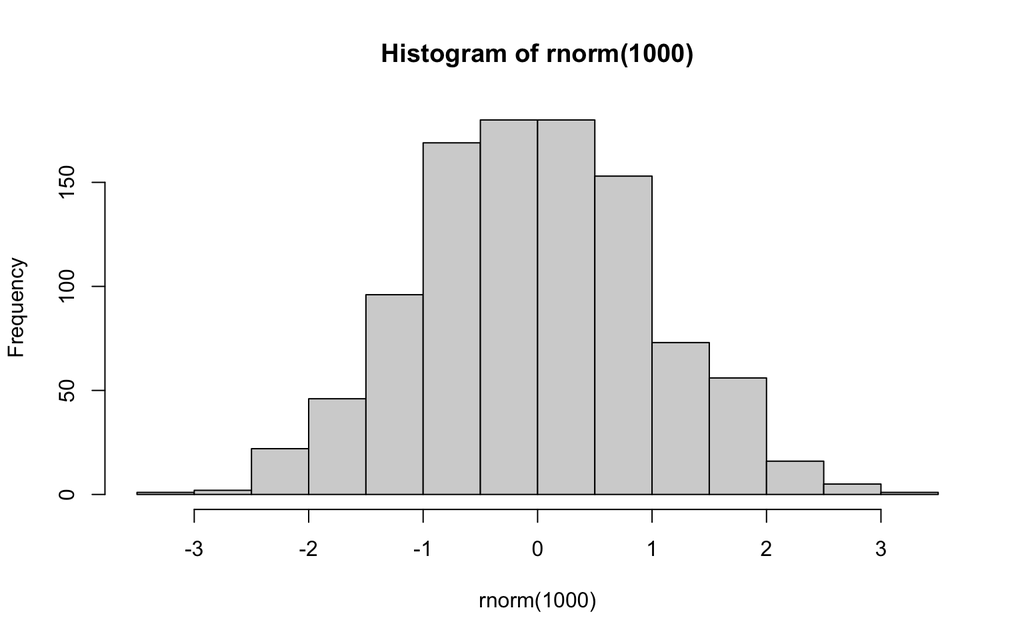

```r
hist(rnorm(1000))
```

## 8.5 rMarkdown. Controlling R code output - eval

Options may be included in the R code chunks.

An important option is to choose whether code will be run or is meant for display only. This can be controlled with the **eval** option. TRUE will evaluate the code.

```r
hist(rnorm(1000))
```

## 8.6 Controlling R code output - Displaying code.

It may be that you wish to report just the results and not include the code used to generate them. This can be controlled with the **echo** argument. TRUE will display the code.

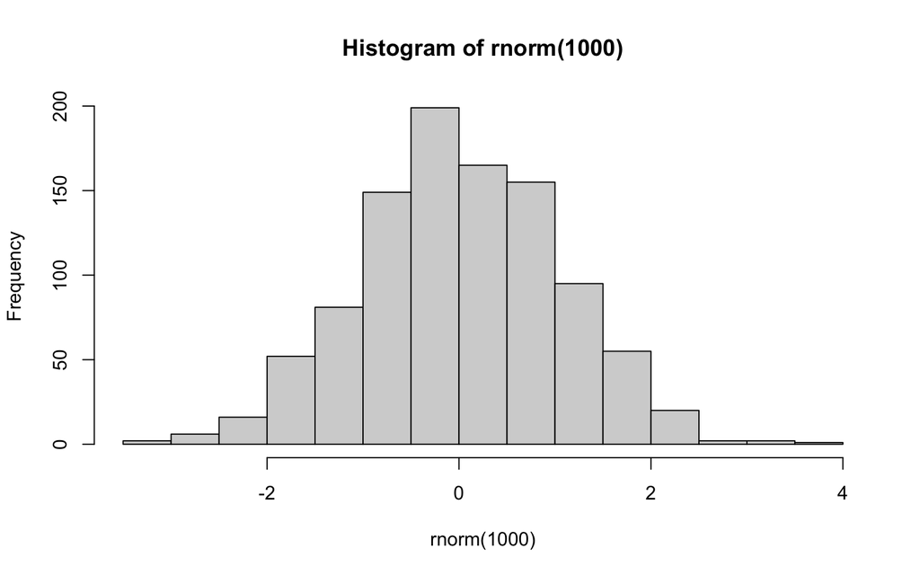

## 8.7 Controlling R code output - message and warnings

R can produce a lot of output not related to your results. To control whether messages and warnings are reported in the rendered document we can specify the **message** and **warning** arguments.

Loading libraries in rMarkdown is often somewhere you would specify these as FALSE.

```r
library(ggplot2)
```

## 8.8 Controlling figure output

Control over figure heights and widths can be implemented in rMarkdown using the **fig.width** and **fig.height** arguments. Further control over exact size in rendered document maybe specified with **out.width** and **out.height**.

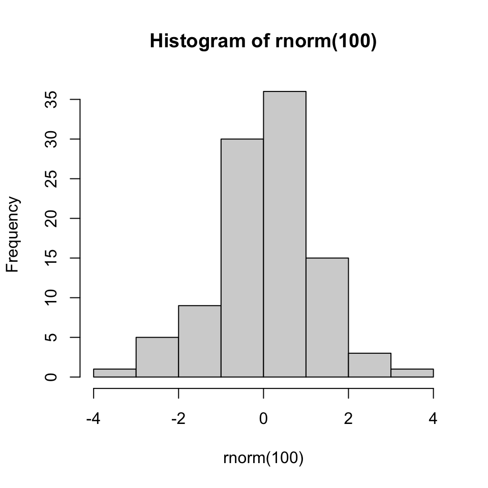

```r
hist(rnorm(100))
```

## 8.9 Placing code and output together

The results of printing data frames or matrices in the console aren’t neat.

We can insert HTML tables into Markdown by setting the **results** option to **asis** and using the knitr function **kable()**

```r
temp <- rnorm(10)
temp2 <- rnorm(10)
dfExample <- cbind(temp,temp2)
library("knitr")
kable(dfExample)
```

| temp | temp2 |
| --- | --- |
| 0.7519604 | 2.2887121 |
| -0.0131316 | -0.1003699 |
| -1.0325529 | 0.1738196 |
| 0.6133599 | 0.0773802 |
| -0.4701668 | 1.5921067 |
| 0.2410400 | 0.8899301 |
| -2.0693142 | 0.2162888 |
| -1.1707616 | -0.6476967 |
| 0.7875492 | -0.2183671 |
| 1.0522116 | -0.7985580 |

## 8.10 Evaluating code within markdown text

It may be useful to report the results of R within the block of Markdown. This can be done adding the code to evalulate within **‘r’**

## 8.11 cache

Some operations may take a significant time or resource to compute.

The **cache** argument may be used to save the results in the current working directory. This code chunk will import the results in future document compilations and save computation time

```r
x <- sample(1000,10^8,replace=T)
length(x)
```

```
## [1] 100000000
```

# 9 YAML in rMarkdown

In rMarkdown the options for document processing are stored in YAML format at the top of the document.

## 9.1 Controlling output type

The **output** YAML option specifies the document type to be produced.

## 9.2 Figure options in YAML

Global default options for figure sizes and devices used can be set within the YAML metadata.

## 9.3 Adding styles

Styles for HTML can be applied using the **theme** option and syntax highlighting styles control by the **highlight** option

For a full list of theme options see - http://rmarkdown.rstudio.com/html_document_format.html

## 9.4 Additional styles

Custom styles can also be applied to rMarkdown documents using CSS style files and the **css** option.

## 9.5 Additional styles

Custom styles can also be applied to rMarkdown documents using CSS style files and the **css** option

## 9.6 Using Rstudio

Lets see how to do this in RStudio.

**File -> New File -> R Markdown**

# 10 Resources

http://yihui.name/knitr/  
http://rmarkdown.rstudio.com/  
http://rcharts.io/  
http://rstudio.github.io/packrat/

# 11 Exercises

- Open up markdownExampleDefaultStyles.Rmd and markdownExample.Rmd in the scripts directory. Have a look at the rMarkdown examples here and the resulting output html files.

Example HTML Default style.  
Example HTML with extra style.

- Open scriptToConvertToRMarkdown.r in scripts directory and save as new name.
- Convert this script to an Rmarkdown document using the render() function or inside RStudio.